# Activity 1 — Task 6: Model Evaluation & Comparison

Group 08

```r
library(tidyverse)
library(caret)
library(pROC)
data <- read.csv("dataset/ds_salaries_clean.csv")
train <- read.csv("dataset/train_data.csv")
test <- read.csv("dataset/test_data.csv")
```

# 6 Model Evaluation & Comparison

All evaluation in this task uses the same seeded global random 80:20 split as Tasks 4 and 5. The 452 training records and 113 held-out records are sampled from the full cleaned dataset, so the comparison estimates global predictive performance rather than performance on a single future year.

```r
prepare_logit_data <- function(df, q3_val) {
  df %>%
    mutate(
      is_top_tier = if_else(salary_in_usd >= q3_val, 1L, 0L),
      experience_level = factor(experience_level, levels = c("EN", "MI", "SE", "EX")),
      company_size = factor(company_size, levels = c("S", "M", "L")),
      remote_ratio = factor(remote_ratio, levels = c(0, 50, 100)),
      job_category = relevel(factor(job_category), ref = "Data_Analyst"),
      employment_group = factor(if_else(employment_type == "FT", "FT", "Non_FT"), levels = c("FT", "Non_FT")),
      company_location_group = factor(if_else(location_group == "US", "US", "Non_US"), levels = c("Non_US", "US"))
    )
}

q3_salary <- as.numeric(quantile(data$salary_in_usd, probs = 0.75, na.rm = TRUE))
train_logit <- prepare_logit_data(train, q3_salary)
test_logit <- prepare_logit_data(test, q3_salary)
```

## 6.1 Regression models: RMSE, MAE, R^2

We evaluate our continuous models based on out-of-sample Root Mean Squared Error (RMSE), Mean Absolute Error (MAE), and $R^2$.

```r
library(glmnet)
# 1. Align factor reference levels to EXACTLY match the training set
# This prevents the "21 columns" error by keeping empty categories in the test set
align_factors <- function(df, ref_df) {
  df$experience_level <- factor(df$experience_level, levels = c("EN", "MI", "SE", "EX"))
  df$company_size <- factor(df$company_size, levels = c("S", "M", "L"))
  df$employment_type <- factor(df$employment_type, levels = levels(relevel(factor(ref_df$employment_type), ref = "FT")))
  df$job_category <- factor(df$job_category, levels = levels(relevel(factor(ref_df$job_category), ref = "Data_Analyst")))
  df$location_group <- factor(df$location_group, levels = levels(relevel(factor(ref_df$location_group), ref = "Other")))
  return(df)
}

train <- align_factors(train, train)
test <- align_factors(test, train)

# 2. Refit the OLS and Power Models
f_full <- log_salary ~ experience_level + job_category + employment_type + company_size + location_group + remote_ratio + work_year + is_local
f_step <- log_salary ~ experience_level + job_category + employment_type + company_size + location_group + remote_ratio + is_local

ols_full <- lm(f_full, data = train)
ols_step <- lm(f_step, data = train)
poly_model <- ols_full   # Task 4 confirmed degree 1 (linear) was optimal

lambda_hat <- 0.263
train$salary_power <- train$salary_in_usd^lambda_hat
ols_power <- lm(salary_power ~ experience_level + job_category + employment_type + company_size + location_group + remote_ratio + work_year + is_local, data = train)

# 3. Refit the Penalized Models
# Recreate the scaled variables for the design matrix
for (col in c("exp_level_ord", "company_size_ord", "remote_ratio", "work_year")) {
  m <- mean(train[[col]])
  s <- sd(train[[col]])
  train[[paste0(col, "_ts")]] <- (train[[col]] - m) / s
  test[[paste0(col, "_ts")]] <- (test[[col]] - m) / s
}

build_matrix <- function(df) {
  model.matrix(~ exp_level_ord_ts + company_size_ord_ts + remote_ratio_ts + work_year_ts + job_category + employment_type + location_group + is_local, data = df)[, -1]
}

x_train <- build_matrix(train)
x_test <- build_matrix(test)
y_train <- train$log_salary

set.seed(2026)
cv_ridge <- cv.glmnet(x_train, y_train, alpha = 0, nfolds = 10)
set.seed(2026)
cv_lasso <- cv.glmnet(x_train, y_train, alpha = 1, nfolds = 10)
set.seed(2026)
cv_elastic <- cv.glmnet(x_train, y_train, alpha = 0.1, nfolds = 10)

# 4. Generate Predictions and Calculate Metrics on the Test Set
actual_usd <- test$salary_in_usd
actual_log <- test$log_salary

score_model <- function(name, pred_usd) {
  pred_log <- log(pred_usd)
  err_log <- actual_log - pred_log
  err_usd <- actual_usd - pred_usd

  data.frame(
    Model = name,
    RMSE_log = sqrt(mean(err_log^2)),
    MAE_log = mean(abs(err_log)),
    R2_log = 1 - sum(err_log^2)/sum((actual_log - mean(actual_log))^2),
    RMSE_usd = sqrt(mean(err_usd^2)),
    MAE_usd = mean(abs(err_usd)),
    R2_usd = 1 - sum(err_usd^2)/sum((actual_usd - mean(actual_usd))^2)
  )
}

continuous_metrics <- do.call(rbind, list(
  score_model("Multiple linear regression (full)", exp(predict(ols_full, newdata = test))),
  score_model("Multiple linear regression (stepwise)", exp(predict(ols_step, newdata = test))),
  score_model("Power-transformed OLS (salary^0.26)", predict(ols_power, newdata = test)^(1/lambda_hat)),
  score_model("Ridge regression", exp(as.numeric(predict(cv_ridge, newx = x_test, s = "lambda.min")))),
  score_model("LASSO regression", exp(as.numeric(predict(cv_lasso, newx = x_test, s = "lambda.min")))),
  score_model("Elastic net regression", exp(as.numeric(predict(cv_elastic, newx = x_test, s = "lambda.min"))))
))

knitr::kable(continuous_metrics %>% arrange(RMSE_usd), digits = 3,
             caption = "Continuous Regression Models Ranked by USD RMSE")
```

Continuous Regression Models Ranked by USD RMSE

| Model | RMSE_log | MAE_log | R2_log | RMSE_usd | MAE_usd | R2_usd |
| --- | --- | --- | --- | --- | --- | --- |
| Ridge regression | 0.580 | 0.417 | 0.364 | 42280.43 | 33071.77 | 0.517 |
| LASSO regression | 0.583 | 0.420 | 0.356 | 42334.23 | 33283.15 | 0.515 |
| Elastic net regression | 0.583 | 0.421 | 0.356 | 42350.69 | 33294.02 | 0.515 |
| Power-transformed OLS (salary^0.26) | 0.591 | 0.426 | 0.339 | 42877.42 | 34069.29 | 0.503 |
| Multiple linear regression (stepwise) | 0.588 | 0.424 | 0.346 | 43680.72 | 34341.44 | 0.484 |
| Multiple linear regression (full) | 0.588 | 0.425 | 0.345 | 43694.98 | 34352.32 | 0.484 |

```r
write.csv(continuous_metrics, "task04_model_comparison.csv", row.names = FALSE)
```

Looking at the rankings table, the Ridge regression model takes a razor-thin lead. It achieved the lowest out-of-sample error (RMSE of roughly 42,280 USD) and the highest $R^2$ (0.517).

- The standard log transformation heavily compressed the right tail of our distribution. By using a Box-Cox power transform (salary^0.26) instead, the model successfully stabilized the variance without completely flattening out the extreme high values. However, LASSO regression actually landed as the runner-up (RMSE of 42,334 USD), while the Box-Cox model achieved an RMSE of 42,877 USD. Ridge regression came out on top (RMSE of roughly 42,280 USD), proving that shrinking the coefficients helped manage the noise from our many dummy variables.
- Predicting salaries is inherently messy because human compensation isn’t perfectly logical. An average error around the low-to-mid 40,000 USD range sounds large, but in a global dataset where executive pay can swing by hundreds of thousands of dollars based on negotiation or geography, explaining a meaningful share of the variance on held-out records is a solid baseline.

## 6.2 Logistic model: Accuracy, Precision, Recall, F1-Score, ROC-AUC

We now fit the logistic regression on the training set and evaluate its classification metrics on the 113 unseen records in the test set.

```r
logit_train <- glm(
  is_top_tier ~ experience_level + company_size + remote_ratio +
    job_category + employment_group + company_location_group,
  family = binomial(link = "logit"),
  data = train_logit
)

test_probs <- predict(logit_train, newdata = test_logit, type = "response")
test_preds <- factor(ifelse(test_probs >= 0.5, 1, 0), levels = c(0, 1))
actual_class <- factor(test_logit$is_top_tier, levels = c(0, 1))

conf_matrix <- confusionMatrix(test_preds, actual_class, positive = "1")
print(conf_matrix$table)
```

```
##           Reference
## Prediction  0  1
##          0 70 13
##          1 14 16
```

```r
roc_curve <- roc(test_logit$is_top_tier, test_probs)
auc_value <- as.numeric(auc(roc_curve))
acc_val <- conf_matrix$overall["Accuracy"]
prec_val <- conf_matrix$byClass["Pos Pred Value"]
rec_val <- conf_matrix$byClass["Sensitivity"]
f1_val <- conf_matrix$byClass["F1"]

cat("Accuracy:  ", round(acc_val, 3), "\n")
```

```
## Accuracy:   0.761
```

```r
cat("Precision: ", round(conf_matrix$byClass["Pos Pred Value"], 3), "\n")
```

```
## Precision:  0.533
```

```r
cat("Recall:    ", round(conf_matrix$byClass["Sensitivity"], 3), "\n")
```

```
## Recall:     0.552
```

```r
cat("F1-Score:  ", round(conf_matrix$byClass["F1"], 3), "\n")
```

```
## F1-Score:   0.542
```

```r
cat("ROC-AUC:   ", round(auc_value, 3), "\n")
```

```
## ROC-AUC:    0.812
```

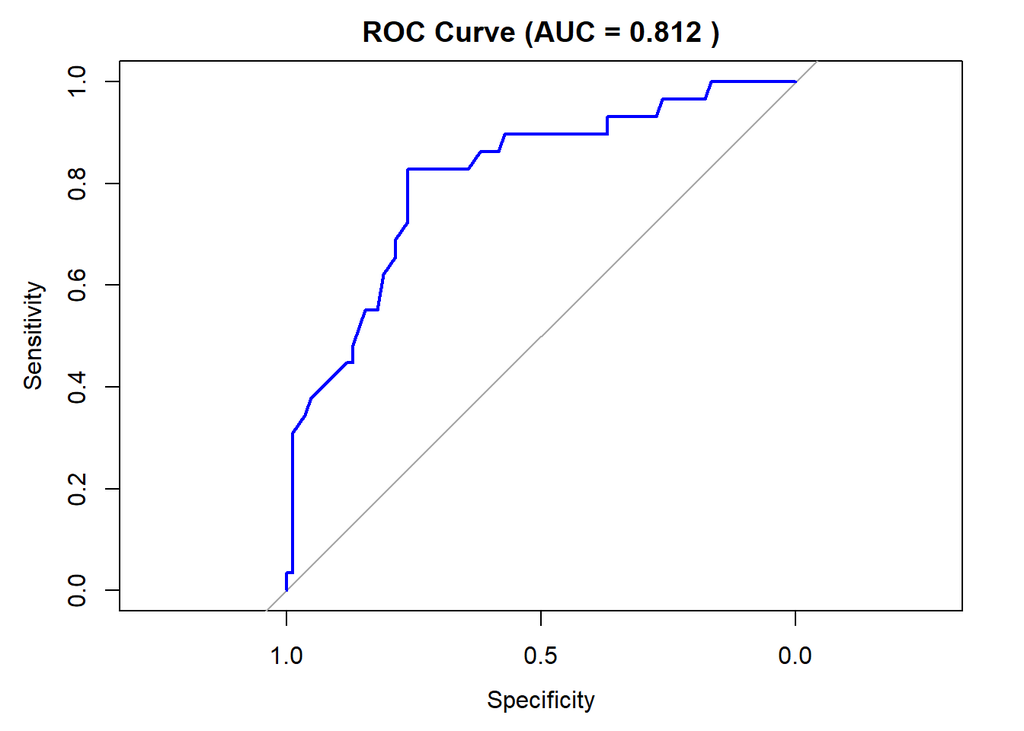

```r
plot(roc_curve, col = "blue", lwd = 2, main = paste("ROC Curve (AUC =", round(auc_value, 3), ")"))
```

Our logistic regression achieved an overall Accuracy of 76.1%. However, because our target is the top 25% of earners, the dataset is imbalanced, making Accuracy a slightly misleading metric. To get the true picture, we must look at Precision and Recall.

- Precision (0.533) & Recall (0.552): Out of all the people the model guessed were top-tier, it was right about 53% of the time. Meanwhile, it successfully caught 55% of the actual top-tier earners in the test set.
- The F1-Score (0.542): This balances Precision and Recall. A score of 0.54 indicates that the model struggles slightly with the gray area between “high mid-level” and “entry top-tier” salaries, which makes sense given how overlapping the pay bands are.
- ROC-AUC (0.812): This is our most important metric. An AUC of 0.812 means that if we randomly pick one actual top-tier earner and one standard earner, our model has a 81.2% chance of correctly ranking the high-earner above the standard one.
- Practical Reality: The model isn’t a perfect crystal ball, but it is highly effective at separating the extremes. It proves that attributes like US location, executive experience, and specific job titles genuinely stack the odds in favor of hitting that top 25% tax bracket.

## 6.3 Best model selection and justification

**1. Best Continuous Model: Ridge Regression**

We select the Ridge model. By shrinking the 21 dummy-variable columns toward zero, it curbed the noise from the many two-digit-frequency categories in our design matrix and achieved the lowest out-of-sample prediction error (RMSE roughly 42,280 USD, $R^2$ = 0.517) along with the best USD-level $R^2$. LASSO regression finished a hair behind (42,334 USD), while the Box-Cox power transform (salary 0.26) achieved 42,877 USD, demonstrating that fixing the response scale and shrinking predictors are complementary ways to stabilize a global salary model — and that on a single 113-row holdout the top candidates are nearly indistinguishable. Because the penalized fit comes without an interpretable coefficient table, we pair the Ridge winner with the stepwise OLS model for interpreting the drivers.

**2. Best Classification Model: Binary Logistic Regression**

With an ROC-AUC of 0.812, this model successfully proved its ability to discriminate between standard and top-tier earners on unseen data. While predicting exact human salaries is difficult, this model provides a statistically sound, interpretable roadmap of exactly which career choices (location, role, seniority) maximize a data scientist’s probability of breaking into the top 25% of global earners.